# Reproducible Research: Peer Assessment 1

## Loading and preprocessing the data

```r
library(readr)
## auto unzip and read csv
activity <- read_csv("activity.zip")
```

## What is mean total number of steps taken per day?

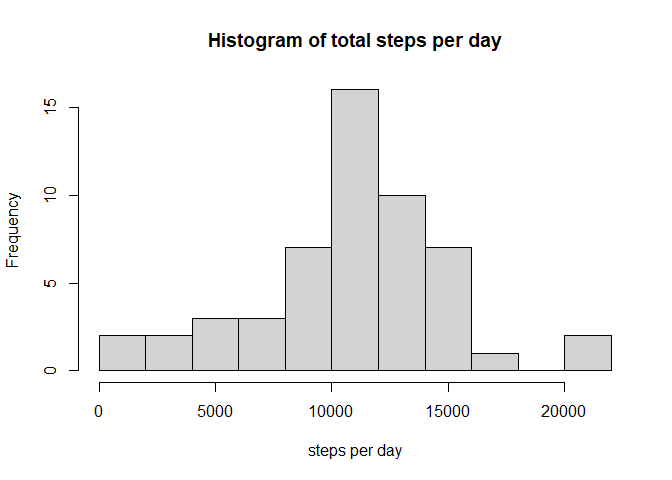

```r
stepsPerDay <- aggregate(steps~date,
                         data = activity,
                         FUN = sum,
                         na.rm = TRUE
                         )
hist(stepsPerDay$steps,breaks = 10, main = "Histogram of total steps per day", xlab = "steps per day")
```

```r
mn <- mean(stepsPerDay$steps)
md <- median(stepsPerDay$steps)
mn
```

```
## [1] 10766.19
```

```r
md
```

```
## [1] 10765
```

```r
ans <- paste("The mean total number of steps is",mn,"steps. The median total number of steps is",md,"steps.")
print(ans)
```

```
## [1] "The mean total number of steps is 10766.1886792453 steps. The median total number of steps is 10765 steps."
```

The mean total number of steps is $1.0766189\times 10^{4}$ steps. The median total number of steps is $1.0765\times 10^{4}$ steps.

## What is the average daily activity pattern?

see plot…

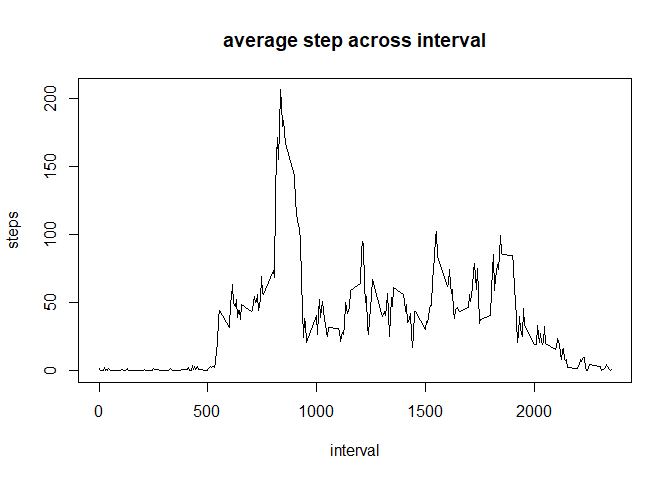

```r
meanStepsPerIntv <- aggregate(steps~interval,
                              data = activity,
                              FUN = mean,
                              na.rm =TRUE
                              )
plot(steps~interval, data = meanStepsPerIntv, type = 'l', main = "average step across interval")
```

```r
## time of day people walk a lot?
walkalot <- meanStepsPerIntv$interval[which.max(meanStepsPerIntv$steps)]
hh <- round(walkalot/60,0)
walkalot
```

```
## [1] 835
```

```r
ans <- paste("people walk the most steps at interval",walkalot,". This is about",hh,": 00 Time.")
print(ans)
```

[output not shown]

## Imputing missing values

First let’s see how many NA values are there

```r
sum(!complete.cases(activity))
```

```
## [1] 2304
```

### impute strategy:

Next let’s decide how to impute the data. we will use mean of 5-min interval 1. find which index need to be imputed 2. find interval of that index 3. get the mean of step on that interval across every day 4. impute the steps in that index

```r
## will impute with mean of each interval, mean taken across all days
NAs <- !complete.cases(activity)
NAindices <- which(NAs)

imputedActivity <- activity
for (i in NAindices){
    missingInterval <- activity$interval[i]
    imputedActivity$steps[i] <- meanStepsPerIntv$steps[meanStepsPerIntv$interval == missingInterval]
}
## count errors before and after
errorCount1 <- sum(NAs)
errorCount2 <- sum(!complete.cases(imputedActivity))
ans <- paste("There was",errorCount1,"errors before imputing and",errorCount2,"error after imputing.")
print(ans)
```

```
## [1] "There was 2304 errors before imputing and 0 error after imputing."
```

there was 2304 errors before imputing. After impute there is 0 error.

### is there affect the distribution?

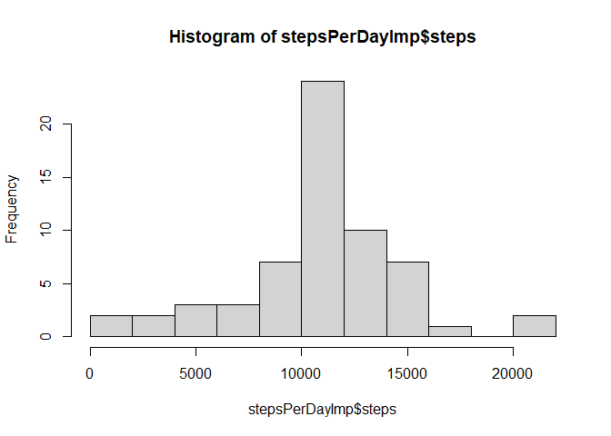

```r
stepsPerDayImp <- aggregate(steps~date,data = imputedActivity, FUN = sum)
hist(stepsPerDayImp$steps, breaks = 10)
```

```r
newmean <- mean(stepsPerDayImp$steps)
newmedian <- median(stepsPerDayImp$steps)
dff <- list(diffmean = newmean - mean(stepsPerDay$steps), diffmed = newmedian - median(stepsPerDay$steps))
print(dff)
```

```
## $diffmean
## [1] 0
##
## $diffmed
## [1] 1.188679
```

the mean do not change, and that is to be expected since we impute using the mean. The median does shift, increasing by 1.1886792 steps per day.

## Are there differences in activity patterns between weekdays and weekends?

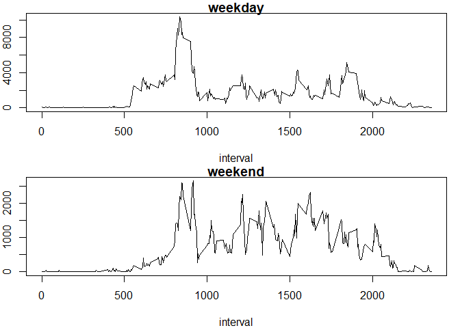

```r
isweekday <- function(dte){
    ifelse(
        weekdays(dte) %in% c("Sunday", "Saturday"),
        FALSE,
        TRUE)
    }
daytype <- as.factor(
    ifelse(
        isweekday(imputedActivity$date),
        "weekday",
        "weekend"
        )
    )
imputedActivity <- cbind(imputedActivity, daytype)

agg<-aggregate(steps~interval+daytype,data = imputedActivity, FUN = sum )
par(mfrow=c(2,1),mar=c(4,2,1,1))
plot(steps~interval,
            data = subset(agg,daytype == "weekday"),
            type='l',
            main = "weekday"
            )
plot(steps~interval,
            data = subset(agg,daytype == "weekend"),
            type='l',
            main = "weekend")
```